# 27 Decision trees and random forests

Author

Affiliation

Vladimir Buskin

Catholic University of Eichstätt-Ingolstadt

## 27.1 Recommended reading

For linguists:

> Levshina (2015): Chapter 14

> Levshina (2020)

> Gries (2021): Chapter 7

General:

> James et al. (2021): Chapter 8

> Hastie, Tibshirani, and Friedman (2017): Chapters 9.2 & 15

## 27.2 Introduction

Decision trees and random forests are very popular **non-parametric** methods. As such, “they do not make explicit assumptions about the functional form of $f$’’ (James et al. 2021: 23).

In this unit, we will cover the conceptual basics of these methods as well as their implementation in R using the `tv` data from Levshina (2020) in addition to the `ELP` data from the unit on Linear Regression. The libraries we will need are listed below:

```r
# Load libraries
library("tidyverse")
library("readxl")
library("tree") # for CART
library("randomForest") # for traditional random forests
library("party") # for Conditional Inference Trees
library("pdp") # for partial dependence plots

## Reaction time data
ELP <- read_xlsx("data/ELP.xlsx")

ELP$POS <- as.factor(ELP$POS)

## Levshina's (2020) data set on T/V forms in Russian
tv <- read.csv("data/Levshina_2020_tv_data.csv", sep = ",", header = TRUE, stringsAsFactors = TRUE)
```

In the `tv` data frame, our target variable will be T/V `Form` with the two outcomes *ty* (Russian 2.p.sg., informal) and *vy* (Russian 2.p.pl., polite).

```r
str(tv)

head(tv)
```

## 27.3 Decision trees

Core concepts:

- **Segmenting the feature space**: “[T]he feature space (i.e., the space spanned by all predictor variables) is recursively partitioned into a set of rectangular areas” (Strobl, Malley, and Tutz 2009: 325).
- **Impurity reduction**: These simplified prediction areas should consist of mostly homogeneous (i.e., ‘pure’ rather than ‘mixed’) observations.
- **Tree construction**: The ‘decisions’ made when partitioning the training data can be visualised using tree structures. The nodes of a tree represent variables, the branches represent decision rules, and leaf nodes indicate the final outcome (e.g., a prediction).
- **CART**: The original computational implementation of decision trees is known as the CART (Classification and Regression Trees) algorithm developed by Breiman (1984).

### 27.3.1 Classification trees

If we are dealing with a **categorical response variable**, the `tree()` function can be used to fit a classification tree in accordance with Breiman’s CART algorithm. For illustration, consider the `tv` data frame. We will model the choice of the pronoun `Form` based on the speaker’s and hearer’s social circle (`Rel_Circle`) and their difference in social class (`Rel_Class`).

```r
# Set random number generator for reproducibility
set.seed(123)

# Supply model formula
tree.tv <- tree(Form ~ Rel_Circle + Rel_Class, data = tv)

# View tree statistics
summary(tree.tv)
```

```
Classification tree:
tree(formula = Form ~ Rel_Circle + Rel_Class, data = tv)
Number of terminal nodes:  9
Residual mean deviance:  0.974 = 213.3 / 219
Misclassification error rate: 0.2412 = 55 / 228
```

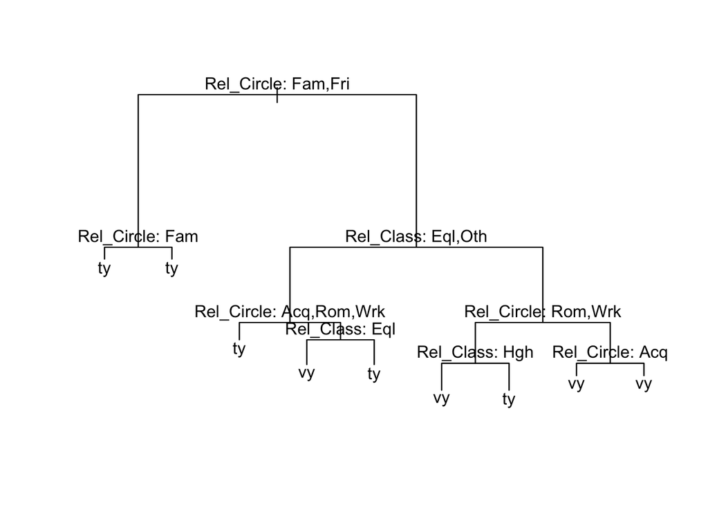

```r
# Visualisation
plot(tree.tv)

text(tree.tv, pretty = 3)
```

An important problem that arises during tree construction is that of **split selection**. When should the tree split a node into two further nodes and when not? Furthermore, when should the tree **stop** the splitting process entirely? In this respect, CART relies on the principle of **impurity reduction**: “The fundamental idea is to select each split of a subset so that the data in each of the descendent subsets are ‘purer’ than the data in the parent subset” (Breiman 1984: 23). A measure for node purity is the **Gini index** $G$, which is defined as

$$G = \sum_{k=1}^{K}{\hat{p}_{mk}(1-\hat{p}_{mk}),}$$

where $\hat{p}_{mk}$ measures the proportion of observations of a response level $k$ in the $m$th prediction area of the training data set. Values close to 0 are indicative of high node purity, meaning that most observations belong to the same class (e.g., `Form = ty`). If splitting a node no longer leads to a substantial increase in purity, it becomes the **terminal node**, i.e., it is not split further. This terminal node returns the tree’s class prediction.

It is worth noting that modern CART implementations rely on different splitting criteria. For instance, **Conditional Inference Trees** use the $p$ values of internal association tests to identify which variables warrant further subdivision of the training data. The presence or absence of correlation thus also determines whether or not a given node will be terminal (for more details, see B. Greenwell 2022: 122).

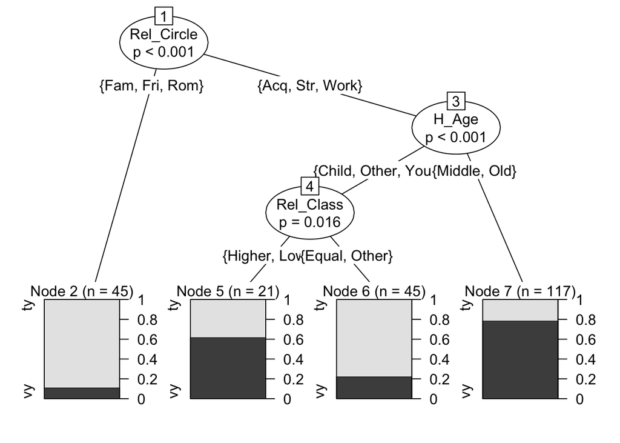

```r
# Fitting a conditional inference tree
ctree.tv <- ctree(Form ~ ., data = tv) # dot . means 'include all predictors'

plot(ctree.tv)
```

### 27.3.2 Regression trees

Regression trees are used for **continuous response variables**. Instead of providing class predictions, they return the mean value of observations in a given prediction area. The algorithm now strives to **minimize the residual sum of squares** ($RSS$). Consider the regression tree for reaction times depending on word length, frequency and part of speech:

```r
# CART tree
tree.rt <- tree(RT ~ Length + Freq + POS, data = ELP)

summary(tree.rt)
```

```
Regression tree:
tree(formula = RT ~ Length + Freq + POS, data = ELP)
Variables actually used in tree construction:
[1] "Freq"   "Length"
Number of terminal nodes:  10
Residual mean deviance:  8629 = 7507000 / 870
Distribution of residuals:
   Min. 1st Qu.  Median    Mean 3rd Qu.    Max.
-220.10  -59.09  -11.17    0.00   49.66  397.40
```

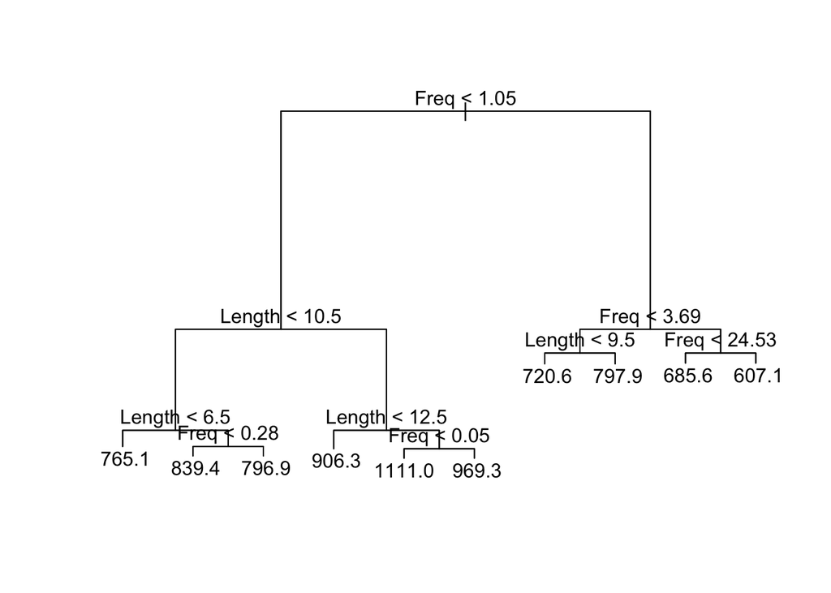

```r
plot(tree.rt)

text(tree.rt, pretty = 0)
```

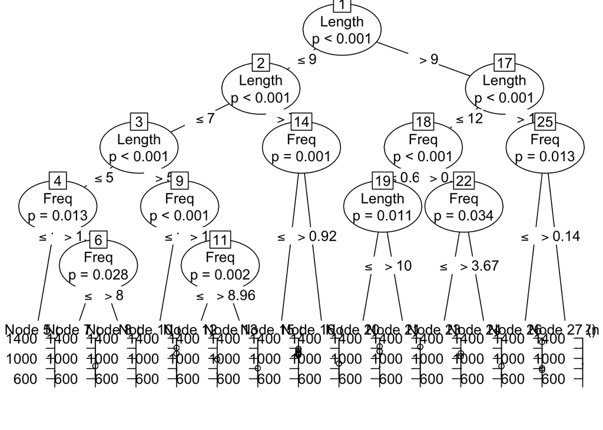

```r
# Conditional inference tree
ctree.rt <- ctree(RT ~ Length + Freq + POS, data = ELP)

plot(ctree.rt)
```

## 27.4 Random forests

Random forests (Breiman 2001) belong to the class of **ensemble methods** because they combine simpler models (e.g., individual decision trees) into a more complex and possibly more accurate model. As part of the RF algorithm, a great number of decision trees is trained on bootstrapped samples of the training data.

So far, random forests are essentially identical with **Bagging** (= bootstrap aggregation); however, an important additional characteristic of the RF algorithm is that only **a random subset of the predictors** is taken into consideration at each split. According to Strobl et al. (2009: 332), the resulting variability in tree structure is advantageous: “By combining the prediction of such a diverse set of trees, ensemble methods utilize the fact that classification trees are unstable, but, on average, produce the right prediction”.

### 27.4.1 Regression forest

For **regression** tasks, random forests return the average prediction of all trees in the ensemble.

```r
# For regression
rt.rf.reg <- randomForest(RT ~ Length + Freq + POS, data = ELP,
                                mtry = 1, # = sqrt(number of variables)
                                ntree = 500) # number of trees

rt.rf.reg
```

```
Call:
 randomForest(formula = RT ~ Length + Freq + POS, data = ELP,      mtry = 1, ntree = 500)
               Type of random forest: regression
                     Number of trees: 500
No. of variables tried at each split: 1

          Mean of squared residuals: 8972.927
                    % Var explained: 43.64
```

```r
# Conditional random forest
rt.crf.reg <- cforest(RT ~ Length + Freq + POS, data = ELP,
                    controls = cforest_unbiased(ntree = 500, mtry = 1))
```

### 27.4.2 Classification forest

For **classification**, all trees cast a vote for one of the response classes. The OOB error estimate refers to the accuracy of **out-of-bag (OOB) predictions**. After the initial bootstrapping procedure, roughly a third of the training data remains unused. These observations, which were not used for fitting trees, can be used as a test data set. Predictions based on this internal test data set are called OOB predictions.

```r
# For classification
tv.rf.class <- randomForest(Form ~ ., data = tv,
                            mtry = 4,
                            ntree = 500)

tv.rf.class
```

```
Call:
 randomForest(formula = Form ~ ., data = tv, mtry = 4, ntree = 500)
               Type of random forest: classification
                     Number of trees: 500
No. of variables tried at each split: 4

        OOB estimate of  error rate: 18.86%
Confusion matrix:
   ty vy class.error
ty 86 22   0.2037037
vy 21 99   0.1750000
```

```r
# Conditional random forest
tv.crf.class <- cforest(Form ~ ., data = tv,
                    controls = cforest_unbiased(ntree = 500, mtry = 4))

tv.crf.class
```

```
     Random Forest using Conditional Inference Trees

Number of trees:  500

Response:  Form
Inputs:  Film, Rel_Age, Rel_Sex, Rel_Power, Rel_Circle, S_Class, H_Class, S_Age, H_Age, Rel_Class, Before68, Others, Office, S_Sex, H_Sex, Place
Number of observations:  228
```

### 27.4.3 Variable importance

Random forests allow users to assess whether or not certain predictors are useful for the model. The **Gini** index can be re-used to identify those variables that have led to the greatest reduction in impurity. However, this measure is **biased** towards predictors with many values (cf. Strobl et al. 2007).

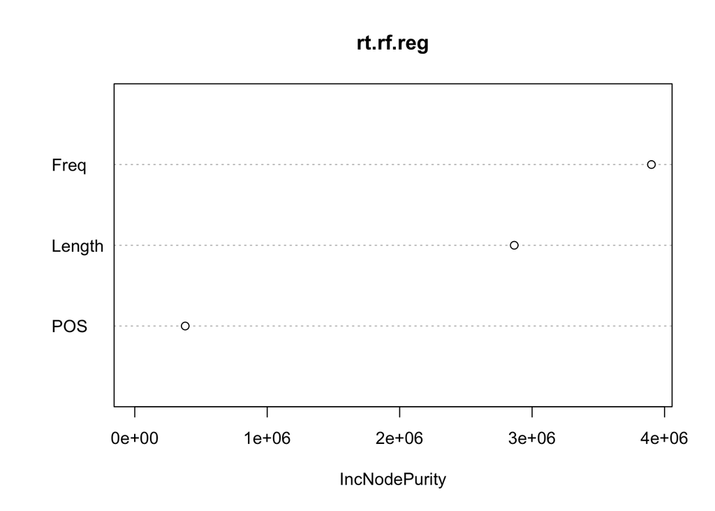

```r
# Gini importance (Reaction times)
varImpPlot(rt.rf.reg)
```

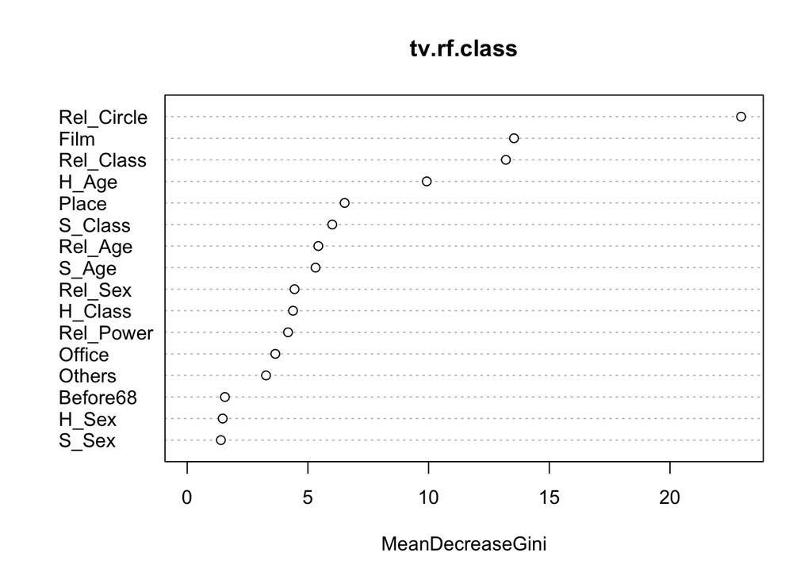

```r
# Gini importance (Form of 2.p.)
varImpPlot(tv.rf.class)
```

A more robust measure is (**Conditional) Permutation Accuracy Importance** which compares the predictive accuracy of the random forest model before and after randomly permuting the values of the predictors (cf. Strobl et al. 2008; Debeer and Strobl 2020).

```r
# Conditional permutation accuracy importance
library("permimp")

# Refit RF model with additional parameters
tv.rf.class <- randomForest(Form ~ .,
                            data = tv,
                            mtry = 4,
                            ntree = 500,
                            keep.inbag = TRUE,
                            keep.forest = TRUE)

# Compute CPI scores
tv.rf.permimp <- permimp(tv.rf.class, conditional = TRUE, progressBar = FALSE, threshold = .95) # Choose "Yes" in the console

# Plot CPI scores
plot(tv.rf.permimp, horizontal = TRUE, type = "dot", sort = TRUE)
```

[output not shown]

### 27.4.4 Visualising random forest models

Partial dependence plots provide averaged predictions $\hat{y}$ for a given constellation of predictors. These averages are produced by the partial dependence function $f_k$. If a categorical response variable has $K$ possible values, it has the form
$$f_k(X) = \log [p_k (x)] - \frac{1}{N}\sum_{k=1}^{K} \log [p_k (x)],$$
with $p_k(x)$ corresponding to the fitted probability of the 𝑘th level of the response variable for $k \in \{1, 2, ..., K\}$ (B. M. Greenwell 2017: 430; see also Hastie, Tibshirani, and Friedman 2017).

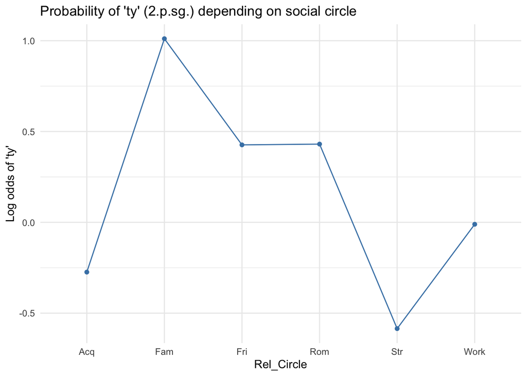

```r
# Form ~ Rel_Circle
Rel_Circle.partial <- pdp::partial(tv.rf.class, pred.var = "Rel_Circle", which.class = "ty")

Rel_Circle.partial %>%
  ggplot(aes(x = Rel_Circle, y = yhat, group = 1)) +
  geom_point(col = "steelblue") +
  geom_line(col = "steelblue") +
  theme_minimal() +
  labs(
    title = "Probability of 'ty' (2.p.sg.) depending on social circle",
    y = "Log odds of 'ty'"
  )
```

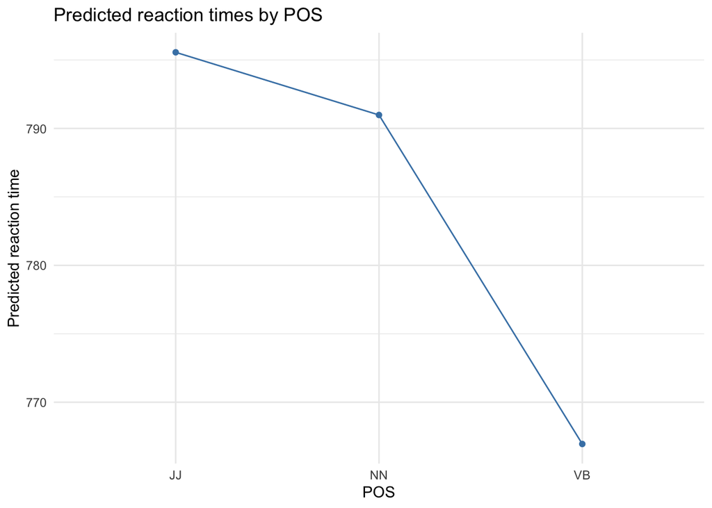

```r
# RT ~ POS
pos.partial <- pdp::partial(rt.rf.reg, pred.var = "POS")

pos.partial %>%
  ggplot(aes(x = POS, y = yhat, group = 1)) +
  geom_point(col = "steelblue") +
  geom_line(col = "steelblue") +
  theme_minimal() +
  labs(
    title = "Predicted reaction times by POS",
    y = "Predicted reaction time"
  )
```

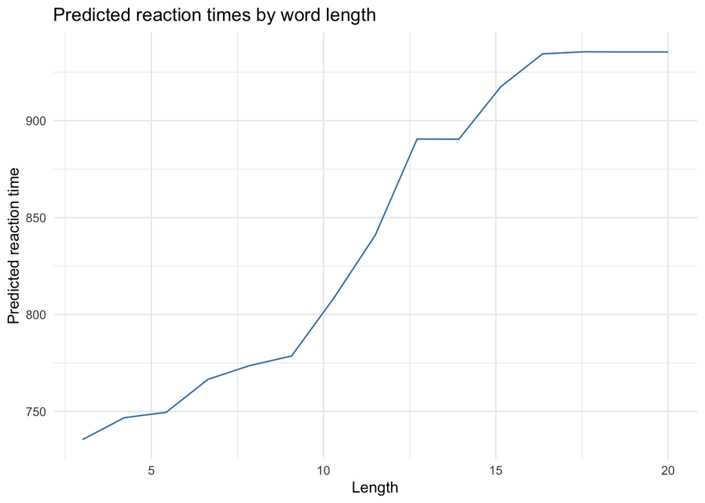

```r
# RT ~ Length
length.partial <- pdp::partial(rt.rf.reg, pred.var = "Length")

length.partial %>%
  ggplot(aes(x = Length, y = yhat)) +
  geom_line(col = "steelblue") +
  theme_minimal() +
  labs(
    title = "Predicted reaction times by word length",
    y = "Predicted reaction time"
  )
```

Breiman, Leo. 1984. *Classification and Regression Trees*. Belmont, Calif.: Wadsworth International Group.

———. 2001. “Random Forests.” *Machine Learning* 45 (1): 5–32. https://doi.org/10.1023/A:1010933404324.

Debeer, Dries, and Carolin Strobl. 2020. “Conditional Permutation Importance Revisited.” *Bioinformatics* 21 (1): 307.

Greenwell, Brandon. 2022. *Tree-Based Methods for Statistical Learning in r*. London & New York: Taylor & Francis Group. https://search.ebscohost.com/login.aspx?direct=true&scope=site&db=nlebk&db=nlabk&AN=3288358.

Greenwell, Brandon M. 2017. “Pdp: An r Package for Constructing Partial Dependence Plots.” *The R Journal* 9 (1): 421–36.

Gries, Stefan Thomas. 2021. *Statistics for Linguistics with r: A Practical Introduction*. 3rd rev. ed. Berlin; Boston: De Gruyter Mouton.

Hastie, Trevor, Robert Tibshirani, and Jerome H. Friedman. 2017. *The Elements of Statistical Learning: Data Mining, Inference, and Prediction*. 2nd ed. New York, NY: Springer.

James, Gareth, Daniela Witten, Trevor Hastie, and Robert Tibshirani. 2021. *An Introduction to Statistical Learning: With Applications in r*. New York: Springer. https://doi.org/10.1007/978-1-0716-1418-1.

Levshina, Natalia. 2015. *How to Do Linguistics with r: Data Exploration and Statistical Analysis*. Amsterdam; Philadelphia: John Benjamins Publishing Company.

———. 2020. “Conditional Inference Trees and Random Forests.” In *A Practical Handbook of Corpus Linguistics*, edited by Magali Paquot and Stefan Thomas Gries, 611–43. Cham: Springer.

Strobl, Carolin, Anne-Laure Boulesteix, Thomas Kneib, Thomas Augustin, and Achim Zeileis. 2008. “Conditional Variable Importance for Random Forests.” *BMC Bioinformatics* 9 (1): 307.

Strobl, Carolin, Anne-Laure Boulesteix, Achim Zeileis, and Torsten Hothorn. 2007. “Bias in Random Forest Variable Importance Measures: Illustrations, Sources and a Solution.” *BMC Bioinformatics* 8 (1): 25.

Strobl, Carolin, James Malley, and Gerhard Tutz. 2009. “An Introduction to Recursive Partitioning: Rationale, Application, and Characteristics of Classification and Regression Trees, Bagging, and Random Forests.” *Psychological Methods* 14: 323–48. https://doi.org/10.1037/a0016973.